# Chasing Half-Lives: Stakeholder Dynamics in Nuclear Medicine

- Show All Code
- Hide All Code
- View Source

Balancing Public Mandates with Private Profit

Author

Dr. Cameron B. Chiarot

## Background

A major metropolitan teaching hospital functions within a publicly funded healthcare system grappling with escalating costs and structural deficits. To augment revenue, the hospital’s Chief Innovation Officer is assessing commercial strategies to monetize the hospital’s underutilized, state-of-the-art Cyclotron Facility (“facility”). This facility produces medical isotopes with short half-lives, including the tracer fluorodeoxyglucose (FDG). Short half-life, medical-grade isotopes are utilized in advanced medical diagnostic imaging techniques such as positron emission tomography (PET) for the detection of cancerous nodules. The facility’s consistent annual budget is entirely financed by the regional health authority under a singular condition: the prioritization of local publicly insured patients, ensuring that clinical wait times remain below two weeks. However, subsequent to a recent hardware enhancement, the cyclotron possesses substantial excess production capacity. Allowing this capacity to remain unused constitutes a squander of an asset that could serve as a novel, low-risk source of recurring annual revenue.

## The Dilemma

The teaching hospital engaged an external consultant to produce a written assessment of the potential untapped market for medical-grade isotopes, aiming to leverage the facility to realize economies of scale and establish a new revenue stream. In the comprehensive report, the consultant outlined two viable business models to use the facility’s surplus capacity, both of which involve intricate stakeholder interactions (and potential friction).

#### Model 1: The Cross-Border Export Strategy

The hospital would dispatch bulk isotopes to private nuclear pharmacy chains in a neighboring country. While highly profitable, this model prompts rigorous regulatory scrutiny from the federal drug administration of the neighboring nation, which mandates strict compliance with site manufacturing standards. Moreover, due to the rapid decay of the isotopes, the model depends entirely on specialized, third-party logistics providers; any delay in flight or transit entirely negates the product’s value.

#### Model 2: The Public-Private Partnership (PPP)

The hospital aims to collaborate with private investors to establish a new private payer imaging clinic directly on the hospital campus. This strategy effectively circumvents issues related to cross-border shipping decay and international regulations. However, this model encounters considerable opposition from the regional health authority and local policymakers, who are concerned that the integration of a private healthcare tier within the public hospital premises may entail significant political risks.

## Organizational Culture

Meanwhile, the internal Director of the facility and the scientific personnel demonstrate a strong commitment to safeguarding their academic agendas. They decline to endorse either model if commercial production phases jeopardize their dedicated laboratory and research periods.

#### Exhibit 1: Annual Baseline Facility Operations & Projections

*Note:* Y = Annualized Fiscal Year; P = Projected Gross Revenue; MoH = Ministry of Health.

[output not shown]

## In-Class Group Exercise

#### Executive Prompt & Objective

Assume the role of your Group’s strategic advisory team. You are standing before the Chief Innovation Officer to pitch a definitive path forward for the underutilized cyclotron facility. Your recommendation(s) must be grounded in a rigorous stakeholder analysis.

## Deliverable

#### Slide 1: Stakeholder Map

- **Stakeholder Mapping:** Map a minimum of 5 core stakeholders based on their Power & Interest scores.
- **Visualization:** Plot the stakeholder groups within the standard matrix quadrants.

#### Slide 2: Proposed Strategy & Recommendation(s)

- **Stakeholder Focus:** Identify the single most critical stakeholder group from your map whose buy-in is essential for project success.
- **Alignment Strategy:** Propose an actionable intervention for the CIO to secure their alignment and mitigate resistance.
- **Model Selection & Rationale:** Recommend either Model 1 (Export) or Model 2 (PPP), explaining how your stakeholder alignment strategy makes this model viable.
- **The CIO Pitch:** Summarize your overall recommendation in a concise final pitch to executive leadership.

## Time Breakdown

**Group Work Objectives (60 Minutes Total)**

- **Slide 1:** Stakeholder Map (i.e., matrix)
- **Slide 2:** Strategy Pitch

**NoteTime Allocation**

- **5 min:** Individual (Case Study reading)
- **20 min:** Group collaboration (Plot & Slides)
- **3 min:** Group pitch (1-2 members)
- **2 min:** Q & A (all members)

## Presentation Order

**Block A**

**1.** Group 4  
**2.** Group 1  
**3.** Group 6

**Block B**

**4.** Group 2  
**5.** Group 5  
**6.** Group 3

# Matrix Generation Tool

To avoid spending time manually drawing shapes and aligning text boxes in presentation software, run the `R` script below to instantly generate your group’s standardized Power vs. Interest Grid.

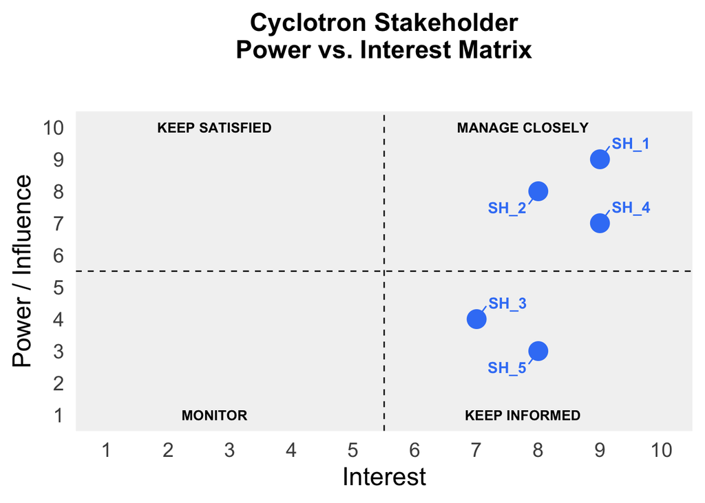

```r
library(ggplot2) # Plotting library
library(ggrepel) # Ensures stakeholder labels don't overlap

# Input your stakeholders and Power/Interest scores (Scale: 1 to 10)
stakeholder_data <- data.frame(
  Stakeholder = c("SH_1", "SH_2", "SH_3", "SH_4", "SH_5"),
  Power = c(9, 8, 4, 7, 3),
  Interest = c(9, 8, 7, 9, 8)
)

# Generate the Power vs. Interest Grid
ggplot(stakeholder_data, aes(x = Interest, y = Power, label = Stakeholder)) +

  # Add coloured quadrant background zones
  annotate("rect", xmin = 5.5, xmax = 10.5, ymin = 5.5, ymax = 10.5,
           fill = "gray90", alpha = 0.5) + # Manage Closely
  annotate("rect", xmin = 0, xmax = 5.5, ymin = 5.5, ymax = 10.5,
           fill = "gray90", alpha = 0.5) + # Keep Satisfied
  annotate("rect", xmin = 0, xmax = 5.5, ymin = 0, ymax = 5.5,
           fill = "gray90", alpha = 0.5) + # Monitor (Low Priority)
  annotate("rect", xmin = 5.5, xmax = 10.5, ymin = 0, ymax = 5.5,
           fill = "gray90", alpha = 0.5) + # Keep Informed

  # Add quadrant dividing lines at the midpoint (5.5)
  geom_vline(xintercept = 5.5, linetype = "dashed", color = "gray10") +
  geom_hline(yintercept = 5.5, linetype = "dashed", color = "gray10") +

  # Plot stakeholder data points
  geom_point(color = "#3B82F6", size = 6) +

  # Automatically adjust labels to prevent overlap using ggrepel
  geom_text_repel(box.padding = 0.5, fontface = "bold", color = "#3B82F6") +

  # Quadrant Titles
  annotate("text", x = 7.75, y = 10,
           label = "MANAGE CLOSELY",
           fontface = "bold", size = 3.5, color = "black") +
  annotate("text", x = 2.75, y = 10,
           label = "KEEP SATISFIED",
           fontface = "bold", size = 3.5, color = "black") +
  annotate("text", x = 2.75, y = 1,
           label = "MONITOR",
           fontface = "bold", size = 3.5, color = "black") +
  annotate("text", x = 7.75, y = 1,
           label = "KEEP INFORMED",
           fontface = "bold", size = 3.5, color = "black") +

  # Scales and Theme Settings
  coord_cartesian(xlim = c(0.5, 10.5), ylim = c(0.5, 10.5)) +
  scale_x_continuous(breaks = 1:10, expand = c(0, 0)) +
  scale_y_continuous(breaks = 1:10, expand = c(0, 0)) +

  # Titles & Labels
  labs(
    title = "Cyclotron Stakeholder\nPower vs. Interest Matrix",
    subtitle = "",
    x = "Interest",
    y = "Power / Influence"
  ) +
  theme_minimal(base_size = 18) +
  theme(
    plot.title = element_text(face = "bold", color = "black",
                              hjust = 0.5, size = 18),
    panel.grid = element_blank()
  )
```

**Copyright & Academic Reproduction Notice**

© 2026 Dr. Cameron B. Chiarot. All rights reserved.

This case study is based on professional executive leadership experience and is intended solely for educational use in academic and professional development settings. No part of this publication may be reproduced, stored in a retrieval system, or transmitted in any form or by any means—electronic, mechanical, photocopying, recording, or otherwise—without the prior express written permission of the author.

**{end}**